# DistractLess

A small program meant to keep you focused by closing websites and programs matching different set of rules regarding their window/tab name and URL

NOT finished by any means. First version is operational. Documentation is in the works, but won’t be published for some time, because I have more important things to do right now.

Manual version 1.0

# 1. Fundamentals

DistractLess is a program designed to shut down distracting programs and browser tabs as soon as they gain focus. It does so by comparing the current window’s title against your sets of whitelisted and blacklisted criteria. Depending on the type of the criteria, a URL can be compared as well.

For more information, see 5. Understanding the filter mechanism

# 2. The GUI

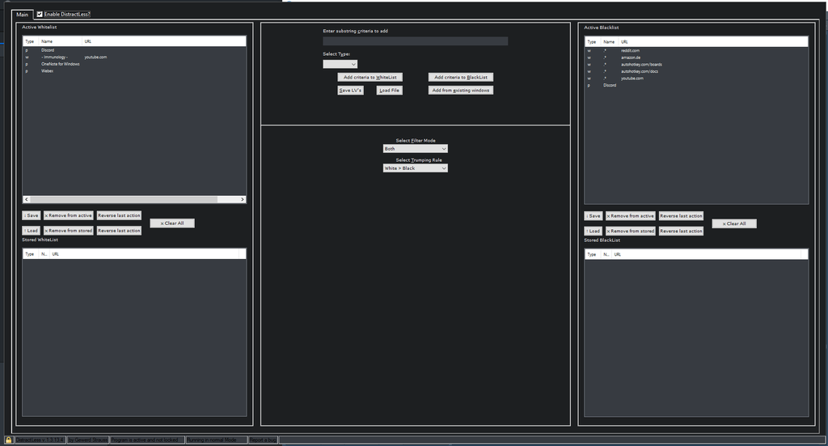

Figure 1: The Main Window

The main overlay can be broken up into three different sections: The left section displays stored and active *whitelisted* strings. The right third displays *blacklisted* ones.

The middle section allows the creation of new conditions, the loading from and saving to a file (both in the upper section) and to quickly change the program behaviour (lower section)

## 2.1. Adding a criterium to a list

### 2.1.1. Criteria

Criteria are split into two categories:

1. programs
2. websites

Both are exclusively checked depending on the current window.

### 2.1.1.1. Browser matches

The rules to detect a browser are predefined for the following browsers out of the box:

1. Google Chrome
2. Mozilla Firefox
3. Internet Explorer
4. Microsoft Edge
5. Opera

To edit these rules, open the settings (cf. Changing program settings) and edit the comma-separated lists of `BrowserClasses`, `BrowserExes` according to the instructions there. Any window matching both of these lists is considered a browser window.

A browser match requires the “website”-type to be selected.

### 2.1.1.2. Program matches

A program, for DistractLess, is any application that is not considered a browser - and therefore doesn’t match the `BrowserClasses` and `BrowserExes` with their respective class and exe as displayed by the window spy. For people who don’t have autohotkey itself installed and are using the compiled version of the window spy in `DistractLess\includes\DistractLess_WindowSpy.exe`. Keep the window open and click on the browser you want to add.

- the first line displays the window title of the currently active window
- the string displayed *behind* “ahk_class” (without the space inbetween, *just* whatever comes after the space) must be added to BrowserClasses in the settings.
- the string displayed *behind* “ahk_exe” (without the space inbetween, *just* whatever comes after the space) must be added to BrowserExes in the settings.
- the last line is absolutely irrelevant for the scope of this application.

You can ignore the first and last line of this first field (under “Window Title, Class and Process”), as well as all other info displayed.

Now that you have added any possible browsers you might be using, let’s go over *programs* (remember, those have distinctly nothing in common with the settings you have just edited.)

A program is only matched according to its window title against any *p*rogram-condition currently visible within the top two listviews visible in figure 1.

### 2.1.2. Syntax

DistractLess always checks if the current window’s title *contains* the substring. There is no distinction made between upper and lowercase, only the order of symbols must match anywhere within the current window’s title.

To have a criteria match any title, set the title string to `.*`.

A few notes: 1. this must be the only element in the substring criteria 2. it cannot be applied to **blacklisted programs**, but to blacklisted websites which have a specific url on which they act. 3. this cannot be implemented for URL-wildcards (you cannot set title substring AND website url to ".*" simultaneously)

These restrictions are necessary so the program doesn’t suddenly start closing everything in an uncontrollable manner.

### 2.1.3. Adding an existing window’s conditions

When the main gui (cf. Figure 1) is open, you can press `Alt+e` to launch a helper-tool for setting conditions faster.

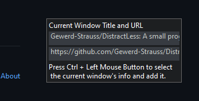

Figure 3: Choose a condition from existing windows

After the window of figure 3 opens, navigate to the desired program/browser tab and press Ctrl+Left Mouse **onto that window**. The respective title (and url if it is considered a browser) are added into the edit fields seen in figure 4. The conditions’ type (website or program) is selected automatically. Edit the substring to a suitable level of specificity and the url possibly and decide wether or not to add it as a blacklist- or whitelist-criteria. If you want to generalise a certain criteria, replace title or URL substring with ".*", according to the rules displayed in syntax.

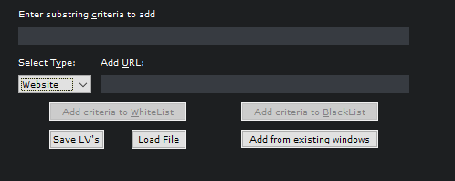

Figure 4: Create a (website) condition

Alteratively, you can just create your conditions by hand, but usually that will be more prone to error and take longer :P

Pressing `Save LV's` will open a dialogue to save the current configuration for later access. The default folder can be changed under `sLocationUserBackup` in the settings.

### 2.2. The lower middle section: The filter mechanism

The program has three filter-modes.

#### 2.2.1. Both

The easiest to use, fastest to balance mode. Rules for the “Both”-mode:

##### 2.2.1.1. White>Black

1. If both the whitelist and blacklist contain a matching entry, the window/browser tab is not closed.
2. If only black contains a matching criterium, and whitelist does not match at all, the window/website *is* closed.

##### 2.2.1.2. Black>White

As soon as blacklist matches the current window/browser tab, it *is* closed, regardless of wether or not whitelist matches. After I finished implementing this, I realised that it is effectively just a more confusing blacklist-only mode. I might rehaul it at some point to work differently, but I am not sure.

#### 2.2.2. Black Only

As soon as a window matches a criteria, it is closed.

#### 2.2.3. White Only*

This option is only available if the setting “bAllowWhiteOnly” is checked in the settings. This extra barrier of entry is necessary because this mode is extremely restrictive. Under its ruleset, *any* window not explicitly matching *any one* condition of the whitelist is closed.

When setting up criteria sets for this mode, please ensure you are running in diagnostics mode first.

A detailed flowsheet of each mode can be found in 5. Understanding the filter

### 3. Accessing and editing the settings

Each setting comes with a small description about its usecase, and possible options. The type of the input is displayed, as well as a default value which is restored when pressing “Restore”. Settings are saved automatically. In the example of figure 6, we are looking at the `OnExitBehaviour`, and a dropdown-list displays possible options.

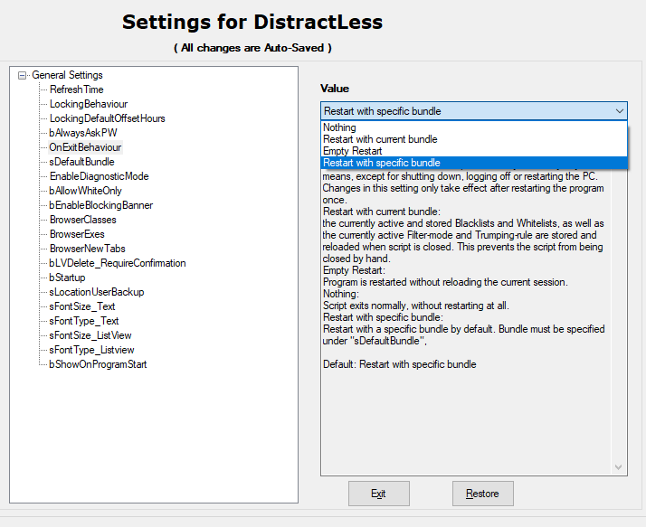

Figure 6: Settings Menu

Figure 7 displays a known, but to me not solvable bug. The description displayed can sometimes be muddied by the display of another setting’s description.

These cases can be identified because the “Default:….”- and “Type:….”- information is displayed twice. In these cases, the *lowest* description is the “correct” one.

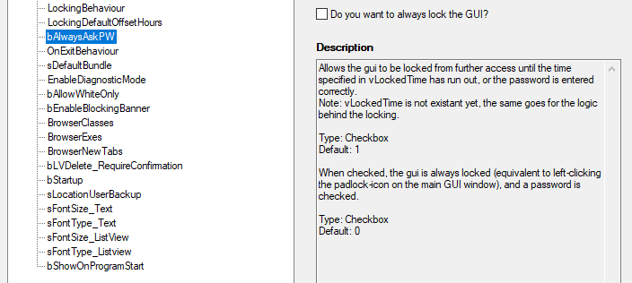

Figure 7: Faulty double description

Settings are autosaved upon change or closing of the window. Most settings take effect immediately, but some require a program restart.

### 4. Entering and exiting diagnostics-mode

In order to enter diagnostics mode, doubleclick the fifth section of the toolbar, saying either “Running in normal mode” or “Running in diagnostics mode”. Doubleclicking will enter and exit that mode.

In diagnostics mode, windows will not be closed. Instead, information on matches that *would have* closed the current window/tab will be displayed. I intend to change this mode so that information on why a particular window is *not* matched will be displayed in those casees as well.

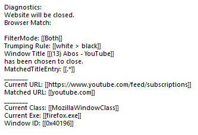

Figure 8: Diagnostics information

Displayed will be

- the type of match (browser match vs program match) - can be useful if you are using browsers that are not defined as such for the program (cf. Browser Matches )
- the current filter mode
- the current trumping rule (always displayed, but only relevant if Filtermode is “Both”)
- the title of the active window which has been matched to close
- the corresponding criteria string that was matched
- the current URL and the matched URL if it is a browser match

### 5. Understanding the filter

At each call to the filtering subroutine, the steps in figure 9 must be passed successfully before the active window’s information is compared.

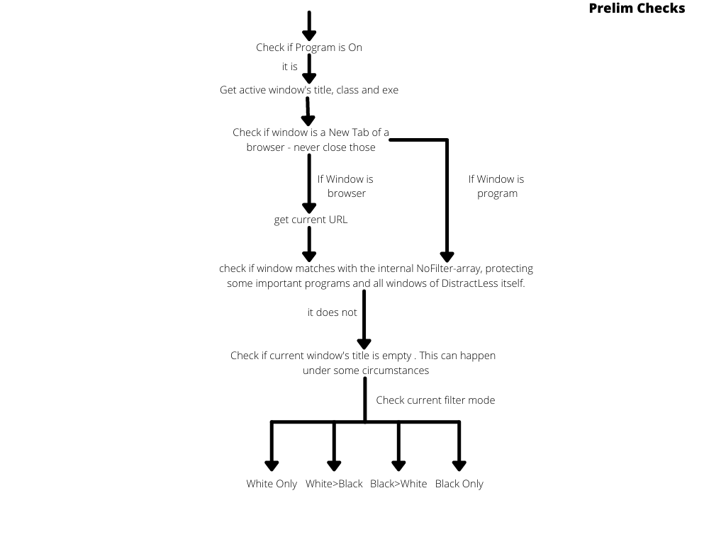

Figure 9: Preliminary Checking routine of the filter

Afterwards, refer to the figures 10-13 for the working mechanisms of the different modes.

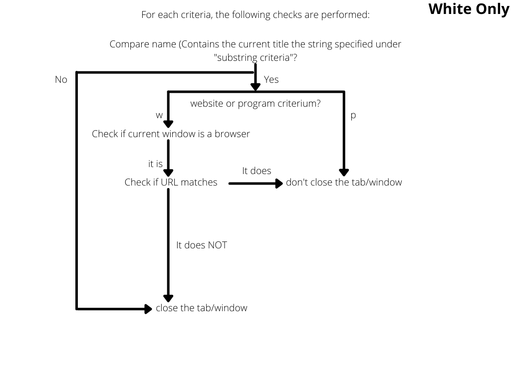

Figure 10: Logic for White-only mode

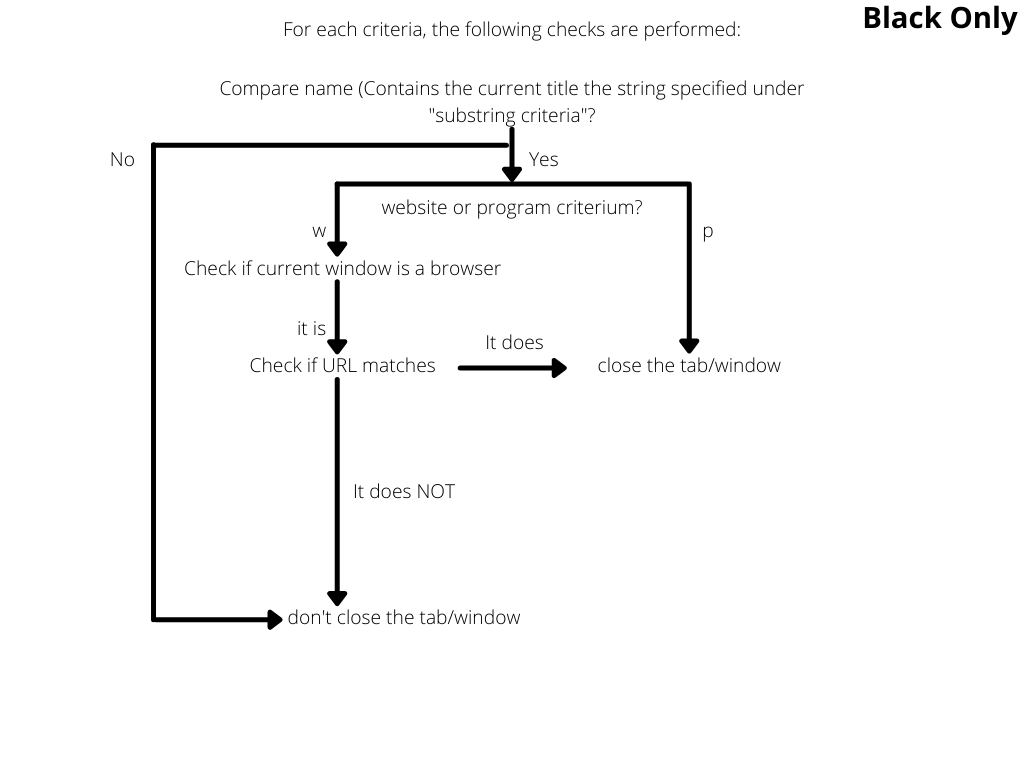

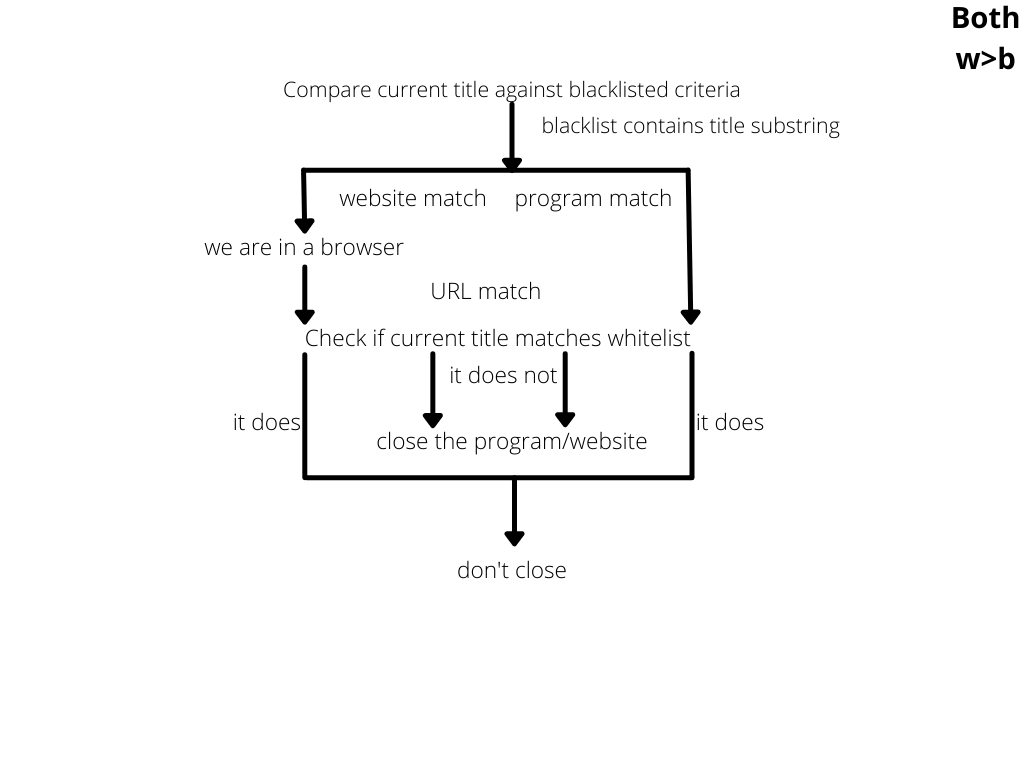

Figure 12: Logic for “Both”-mode, with white trumping black

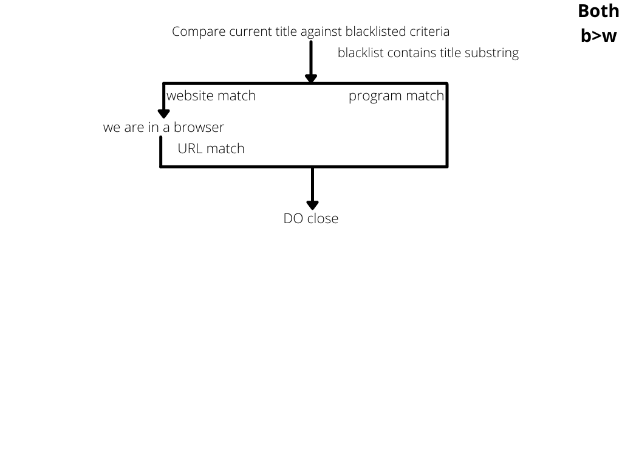

Figure 13: Logic for “Both”-mode, with black trumping white

### 6. Hotkeys

All Hotkeys are active while GUIs are active, and most are restricted to the main-gui, except when noted.

#### 6.1. Main Gui

| Hotkey | Function |
| --- | --- |
| Alt+E | Launch title-adder-tool |
| Escape | Close Gui |
| Ctrl+T | Enter/Exit Testmode (cf. Entering and exiting diagnostics-mode ) |
| Ctrl+L | Lock the Gui |
| Ctrl+O | Open Settings |
| Shift+1 | Focus on WhiteActive Listview |
| Shift+2 | Focus on WhiteStorage Listview |
| Shift+3 | Focus on BlackActive Listview |
| Shift+4 | Focus on BlackStorage Listview |
| Alt+F | Focus on Filtermode Dropdown-List |
| Alt+T | Focus on Trumpingrule Dropdown-List |
| Alt+- | Open Main Gui (active globally) |
| ^ / Sc029 | Toggle on/off program |

Table 1: Main Gui Hotkeys and Accelerator Keys

### 6.2 “Title-Adder”-GUI

Launched by pressing Alt+E, cf. table 1

| Hotkey | Function |
| --- | --- |
| Ctrl+LButton | When pressed *on* a window, choose its info and import it for further processing into main GUI |
| Escape | return to the main gui, don’t add current selection into program |
| Alt+E | When the display in the bottom right corner has focus, pressing Alt+E results in the same outcome as pressing Escape while the Title-Adder-GUI is visible |

Table 2: “Title-Adder” Hotkeys and Accelerator Keys

### 6.3 Submit Password/Time GUI

When entering a password to unlock the GUI[^1] or setting the unlock-time[^2], the following hotkeys are available:

| Hotkey | Function |
| --- | --- |
| Ctrl+Enter | `Time-Protected`: Submit chosen time after which access to the program is possible again. For more info, see 7. Locking the GUI |
| Ctrl+Enter | `Password-Protected`: Confirm Password to unlock the gui |
| Escape/Alt+E | close the respective window and return to main GUI |

Table 3: Hotkeys available when locking/unlocking the GUI via Password/Setting time

### 7. Locking the Gui

You can lock the GUI by pressing `Ctrl+L` while the main GUI is active. There are two locking modes:

### 7.1 Time-Protected

| Hotkey | Function |
| --- | --- |
| Tab / Shift+Tab | cycle forwards/backwards through positions of the select-time-GUI |

Table 4: Additional Hotkeys in the “Select Time”-Gui

If `LockingBehaviour` is set to `Time-protected`, the time at which the GUI is unlocked can be set. The GUI becomes fully locked until the time of day has passed.

By default, the GUI is locked until the third next full hour has passed. I.e. if you lock et 14:49, the default time is calculated to be 17:00:00. Not 18:00:00. See the setting `LockingDefaultOffsetHours` in the settings. Only integers (and therefore full hours) can be preset.

### 7.2 Password-protected

If `LockingBehaviour` is set to `Password-protected`, a password check is performed against the password set by the user during the first time the program has been started. The password submits itself if it is correct.

### 8. Overview over Settings

[output not shown]

Table 5: Settings of the program. All non-bolded settings have little importance and should not necessarily be customised. Inversely, bolded settings are recommended to be edited.

[^1]: Only possible if “LockingBehaviour” in settings is set to “Password-protected”
[^2]: Only possible if “LockingBehaviour” is set to “Time-protected”